# Exploratory Data Analysis

MSDS 6372: Jacob Turner

Isabella Westlauer

2026-11-15

## EDA Objective

Start EDA with the distribution of the target variable, `y`, and then move on to the distribution of the predictors. Inspect dataset for missing values and outliers. Preview correlation between the predictors and the target variable.

## Ingest

```r
library(tidyverse)
library(ggplot2)
library(dplyr)
library(tidyr)

bank_add <- read.csv("../Data/bank-additional-full.csv", sep = ";")
# bank_full <- read.csv("../Data/bank-full.csv", sep = ";")
```

## Distribution of Response

The distribution of the response variable `y` is shown below. The majority of the observations are “no” (not subscribed), with a smaller proportion of “yes” (subscribed). This indicates that the dataset is imbalanced, which may affect the performance of predictive models.

```r
# Distribution of y
table(bank_add$y)
```

```
##
##    no   yes
## 36548  4640
```

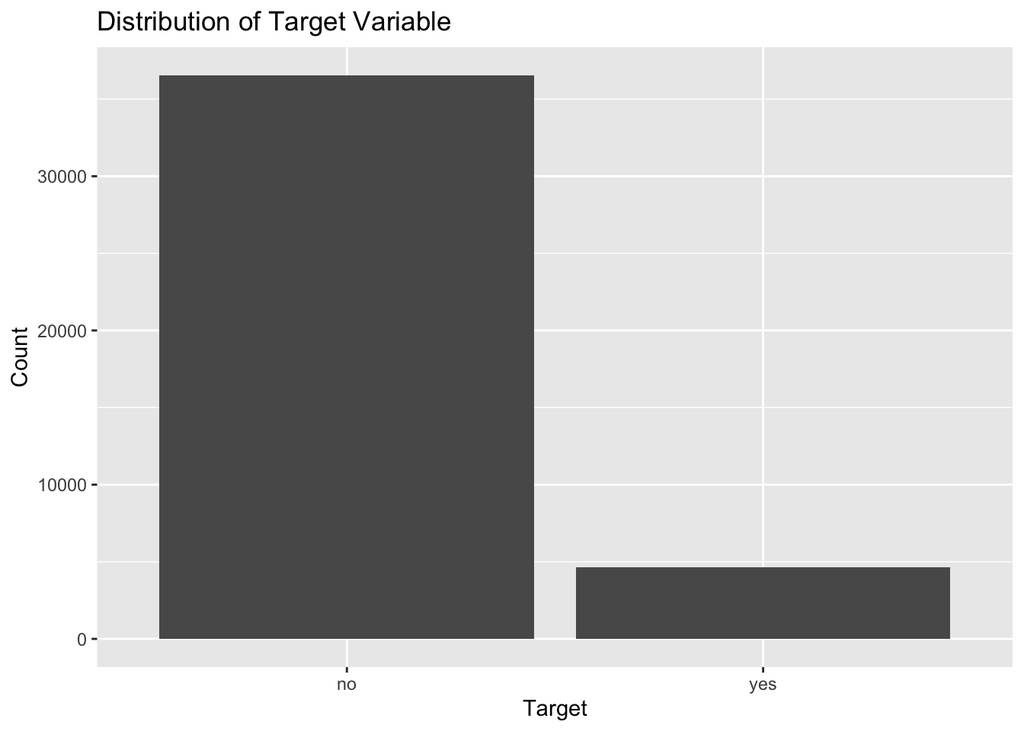

```r
ggplot(bank_add, aes(x = y)) +
  geom_bar() +
  labs(title = "Distribution of Target Variable", x = "Target", y = "Count")
```

## Distributions of Numerical Predictors

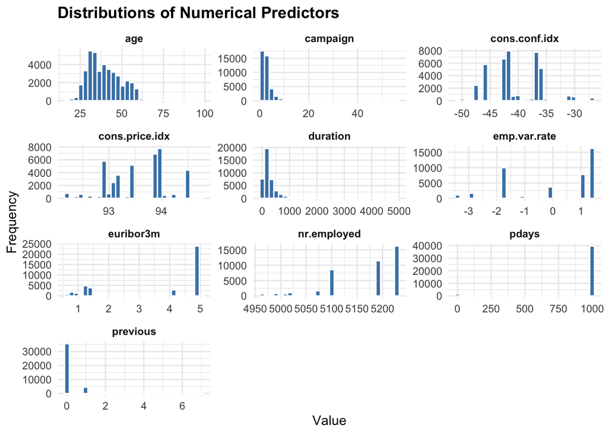

```r
# Identify numerical predictors
num_vars <- bank_add %>%
  select(where(is.numeric)) %>%
  names()

# Convert to long format for faceting
bank_long <- bank_add %>%
  select(all_of(num_vars)) %>%
  pivot_longer(
    cols = everything(),
    names_to = "Predictor",
    values_to = "Value"
  )

# Plot distributions
ggplot(bank_long, aes(x = Value)) +
  geom_histogram(
    bins = 30,
    fill = "steelblue",
    color = "white"
  ) +
  facet_wrap(~ Predictor, scales = "free", ncol = 3) +
  labs(
    title = "Distributions of Numerical Predictors",
    x = "Value",
    y = "Frequency"
  ) +
  theme_minimal() +
  theme(
    strip.text = element_text(face = "bold"),
    plot.title = element_text(face = "bold")
  )
```

## Five Number Summary of Numerical Predictors

```r
# Create a five-number summary table for all numerical predictors
five_num_summary <- data.frame(
  Variable = num_vars,
  t(sapply(bank_add[num_vars], fivenum))
)

# Rename columns
colnames(five_num_summary) <- c(
  "Variable", "Min", "Q1", "Median", "Q3", "Max"
)

# Display as a formatted table
knitr::kable(
  five_num_summary,
  digits = 2,
  caption = "Five-Number Summary of Numerical Predictors"
)
```

Five-Number Summary of Numerical Predictors

|  | Variable | Min | Q1 | Median | Q3 | Max |
| --- | --- | --- | --- | --- | --- | --- |
| age | age | 17.00 | 32.00 | 38.00 | 47.00 | 98.00 |
| duration | duration | 0.00 | 102.00 | 180.00 | 319.00 | 4918.00 |
| campaign | campaign | 1.00 | 1.00 | 2.00 | 3.00 | 56.00 |
| pdays | pdays | 0.00 | 999.00 | 999.00 | 999.00 | 999.00 |
| previous | previous | 0.00 | 0.00 | 0.00 | 0.00 | 7.00 |
| emp.var.rate | emp.var.rate | -3.40 | -1.80 | 1.10 | 1.40 | 1.40 |
| cons.price.idx | cons.price.idx | 92.20 | 93.08 | 93.75 | 93.99 | 94.77 |
| cons.conf.idx | cons.conf.idx | -50.80 | -42.70 | -41.80 | -36.40 | -26.90 |
| euribor3m | euribor3m | 0.63 | 1.34 | 4.86 | 4.96 | 5.04 |
| nr.employed | nr.employed | 4963.60 | 5099.10 | 5191.00 | 5228.10 | 5228.10 |

## Density Plots by Subscription Status

Density Plots grouped by subscription status (`y`) for each numerical predictor. This will help visualize how the distributions differ between those who subscribed and those who did not. The predictors that show potential differences in distribution between the two groups may be more informative for predictive modeling: cons.conf.idx, cons.price.idx, emp.var.rate, euribor3m, nr.employed.

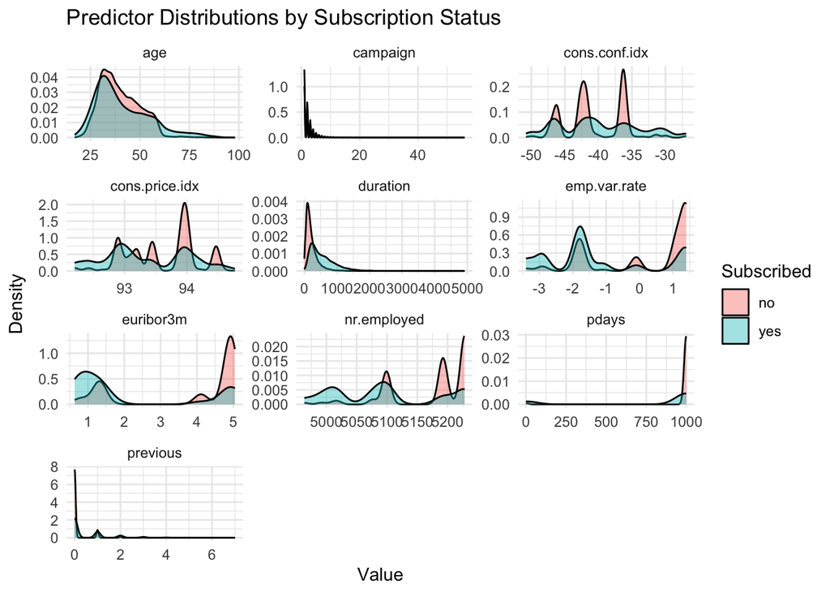

```r
bank_long <- bank_add %>%
  select(all_of(num_vars), y) %>%
  pivot_longer(
    cols = all_of(num_vars),
    names_to = "Predictor",
    values_to = "Value"
  )

ggplot(bank_long, aes(x = Value, fill = y)) +
  geom_density(alpha = 0.4, na.rm = TRUE) +
  facet_wrap(~ Predictor, scales = "free", ncol = 3) +
  labs(
    title = "Predictor Distributions by Subscription Status",
    x = "Value",
    y = "Density",
    fill = "Subscribed"
  ) +
  theme_minimal()
```

## Faceted Bar Charts for Categorical Predictors

Faceted bar charts for categorical predictors: notice that many predictors have ‘unknown’ as a category, which may need to be addressed in the cleaning process.

Also notice pdays, which is a numeric predictor but has a large number of 999 values, indicating that the client was not previously contacted. This may need to be treated as a categorical variable or imputed in some way.

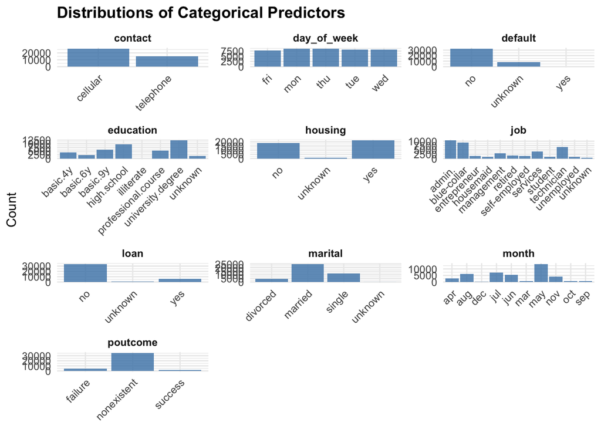

```r
# Identify categorical predictors
cat_vars <- bank_add %>%
  select(where(~ is.factor(.) | is.character(.))) %>%
  select(-any_of("y")) %>%
  names()

# Convert to long format
bank_cat_long <- bank_add %>%
  select(all_of(cat_vars)) %>%
  pivot_longer(
    cols = everything(),
    names_to = "Predictor",
    values_to = "Category"
  )

# Plot categorical predictor distributions
ggplot(bank_cat_long, aes(x = Category)) +
  geom_bar(fill = "steelblue", alpha = 0.8) +
  facet_wrap(~ Predictor, scales = "free", ncol = 3) +
  labs(
    title = "Distributions of Categorical Predictors",
    x = NULL,
    y = "Count"
  ) +
  theme_minimal() +
  theme(
    strip.text = element_text(face = "bold"),
    axis.text.x = element_text(
      angle = 45,
      hjust = 1
    ),
    plot.title = element_text(face = "bold")
  )
```

## Boxplots to examine outliers

Important note: the duration attribute highly affects the output target (e.g., if duration=0 then y=“no”). Yet, the duration is not known before a call is performed. Also, after the end of the call y is obviously known. Thus, this input should **only be included for benchmark purposes** and should be discarded if the intention is to have a realistic predictive model.

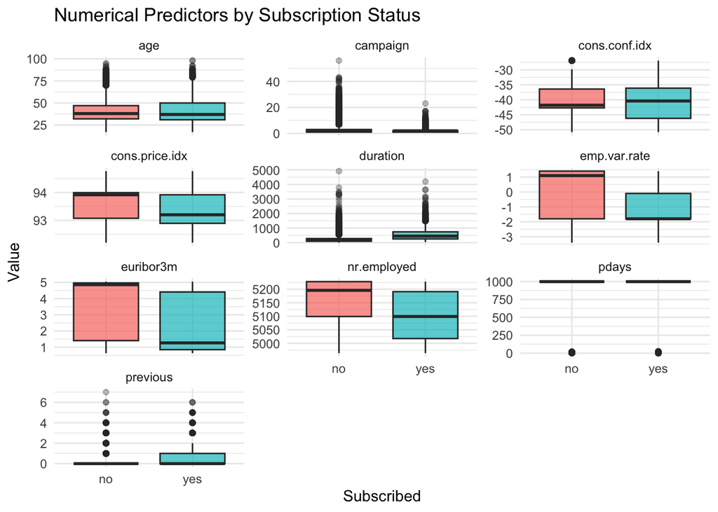

```r
ggplot(bank_long, aes(x = y, y = Value, fill = y)) +
  geom_boxplot(alpha = 0.7, outlier.alpha = 0.3) +
  facet_wrap(~ Predictor, scales = "free_y", ncol = 3) +
  labs(
    title = "Numerical Predictors by Subscription Status",
    x = "Subscribed",
    y = "Value"
  ) +
  theme_minimal() +
  theme(legend.position = "none")
```

## Missing or Unknown Values

There are no missing values in the dataset. However, **default, education, housing, loan, job, and marital** have “unknown” values. The table below shows the proportion of unknown values for each predictor. This will help identify which predictors may need to be cleaned or imputed.

```r
# look for missing values in the dataset
sum(is.na(bank_add))
```

```
## [1] 0
```

```r
# look for unknown values in the dataset
sum(bank_add == "unknown") / sum(bank_add != "unknown")
```

```
## [1] 0.0149232
```

```r
# breakdown the proportion of unknown values by predictor
unknown_summary <- bank_add %>%
  summarise(across(everything(), ~ sum(. == "unknown") / n())) %>%
  pivot_longer(
    cols = everything(),
    names_to = "Predictor",
    values_to = "Proportion_Unknown"
  ) %>%
  arrange(desc(Proportion_Unknown))

# Display results
knitr::kable(
  unknown_summary,
  digits = 3,
  caption = "Proportion of Unknown Values by Predictor"
)
```

Proportion of Unknown Values by Predictor

| Predictor | Proportion_Unknown |
| --- | --- |
| default | 0.209 |
| education | 0.042 |
| housing | 0.024 |
| loan | 0.024 |
| job | 0.008 |
| marital | 0.002 |
| age | 0.000 |
| contact | 0.000 |
| month | 0.000 |
| day_of_week | 0.000 |
| duration | 0.000 |
| campaign | 0.000 |
| pdays | 0.000 |
| previous | 0.000 |
| poutcome | 0.000 |
| emp.var.rate | 0.000 |
| cons.price.idx | 0.000 |
| cons.conf.idx | 0.000 |
| euribor3m | 0.000 |
| nr.employed | 0.000 |
| y | 0.000 |